# Political Ideology of EU Directives and Regulations: Evaluation and Comparison with Ground Truth

2025-01-11

This report explains how the political ideology of EU directives and regulations was calculated and compared to a ground truth dataset.

Three methods were evaluated: the approach by Hix and Høyland (2024), a natural language processing (NLP) approach using latent semantic scaling (LSS) and finally an approach applying large language models (LLMs). The ground truth is based on Nanou, Zapryanova, and Toth (2017).

The comparison shows that the Hix and Høyland (2024) method aligns closest with the ground truth than the other methods.

## Data: Preambles and Summaries of Directives and Regulations between 1989 and 2024

Two sources of natural language data were used in the analysis:

1. **Preambles**: The preamble text of policies was used, as suggested by Hix and Høyland (2024, 12). Text was cut off at “Adopted this directive/regulation”. Preambles were collected from the [CEPS EurLex dataset](https://dataverse.harvard.edu/dataset.xhtml?persistentId=doi:10.7910/DVN/0EGYWY) (Borrett and Laurer 2020), covering about 70,000 directives and regulations from 1989 to 2019. Additional policies from 2019 to August 2024 were collected using the [eurlex](https://michalovadek.github.io/eurlex/) R package (Ovádek 2021), resulting in 74,734 policies total.
2. **Summaries**: EUR-Lex provides summaries for some policies ([example](https://eur-lex.europa.eu/legal-content/EN/LSU/?uri=CELEX:32019L0904&qid=1719922563047)). Summaries are provided by EUR-Lex on a [case-by-case basis](https://eur-lex.europa.eu/browse/summaries.html). A total of 1,637 summaries were scraped from [eur-lex.europa.eu](https://eur-lex.europa.eu/homepage.html?locale=en) using [this script](https://github.com/fabianaiolfi/eu-policy-feedback/blob/main/data_collection/eurlex_summaries.R).

## Methods

### Hix & Høyland

Hix and Høyland (2024, 12) classify 100-word text segments as left, right, or neutral using these methods:

1. **RoBERT Left Right**  
   A [RoBERT classifier](https://huggingface.co/niksmer/RoBERTa-RILE) trained on a corpus of party manifestos.
2. **Bakker Hobolt Econ and Bakker Hobolt Social**  
   A fine-tuned [ManiBERT classifier](https://huggingface.co/niksmer/ManiBERT) that identifies Comparative Manifesto Project (CMP) policy-issue codes. Results are classified as “left” or “right” based on the modified CMP measures in Bakker and Hobolt (2013, 38, Table 2.4).
3. **CMP Left Right**  
   A fine-tuned [ManiBERT classifier](https://huggingface.co/niksmer/ManiBERT) that identifies Comparative Manifesto Project (CMP) policy-issue codes. Results are classified as “left” or “right” using Bakker and Hobolt (2013, 33, Table 2.2) CMP left-right dimension terms.

Each 100-word segment receives a “left,” “right,” or “neutral” tag. The number of tag occurences are summed up and converted into a score using the “logit-scaled left-right position” method from Lowe et al. (2011).

### Latent Semantic Scaling (LSS)

LSS is a method for measuring the semantic similarity between documents and a set of seed words. In this analysis, each directive or regulation is a document and the seed words convey “typical” left-right terms. The semantic similarity between documents and seed words is calculated using word embeddings provided by [GloVe](https://nlp.stanford.edu/projects/glove/). To keep computation efficient, I use the smallest pre-trained word vectors model available (6B tokens, 400K vocab, 50 dimensions). The economic seed words can be viewed [here](https://github.com/fabianaiolfi/eu-policy-feedback/blob/main/lss/seed_words_econ_manual.yml), the social seed words [here](https://github.com/fabianaiolfi/eu-policy-feedback/blob/main/lss/seed_words_social_manual.yml).

### LLM Methods

The LLMs methods use the following models:  
- OpenAI’s [GPT-4o mini](https://openai.com/index/gpt-4o-mini-advancing-cost-efficient-intelligence/), accessed via the [OpenAI API](https://platform.openai.com/docs/overview)  
- Meta’s [Llama 3.2 1B](https://ollama.com/library/llama3.2:1b), used locally via [Ollama](https://ollama.com/)  
- [DeepSeek V3](https://www.deepseek.com/), accessed via their API

Two different methods were applied: **0-shot** and **ranking**.

#### 0-Shot

This method asks the LLM to score a policy on an economic left-right scale of 0 to 100 based on set criteria.

The following prompt was sent:

```
You are an expert in European Union policies. Answer questions and provide information based on that expertise.

[I’m going to show you a summary of an EU policy | I’m going to show you the beginning of a preamble of an EU policy.] Please score the policy on a scale of 0 to 100. 0 represents economic left-wing policies, such as government intervention in the economy, redistribution of wealth, social welfare pr…

…
```

In addition, I queried DeepSeek on a social left-right scale:

```
You are an expert in European Union policies. Answer questions and provide information based on that expertise.

I’m going to show you a summary of an EU policy. Please score the policy on a scale of 0 to 100. 0 represents socially progressive policies, such as support for LGBTQ+ rights, gender equality, racial justice, reproductive rights, inclusive social policies, expansive immigration policies, criminal ju…

…
```

#### Ranking

The ranking method calculates scores by comparing policies directly with each other. To do this, the following steps are taken: Two random policies are presented to the LLM, which decides which policy is more economically left (or right) based on set criteria. The “winning” policy is flagged. Repeating this process many times and recording “winning” and “losing” policies enables the use of the [Elo rating system](https://en.wikipedia.org/wiki/Elo_rating_system) to calculate a score for each policy. Economically left “winning” policies receive a higher “left” score than economically left “losing” policies.

Ranking was only performed on the summaries. Applying this method to the preambles, i.e., over 70,000 documents, would have taken several dozen hours of inference and over $100 in API costs when using ChatGPT.

##### Prompt for Economic Left (Summaries)

```
You are an expert in European Union policies. Answer questions and provide information based on that expertise.

I have two summaries of EU policies, and I need to determine which policy is more economically left-leaning. Please analyze the summaries based on principles commonly associated with economically left policies, such as government intervention in the economy, redistribution of wealth, social welfare …

Policy Summary 1
…

Policy Summary 2
…

Which policy is more economically left? Please answer ONLY '1' or '2', NOTHING ELSE UNDER NO CIRCUMSTANCES.
```

##### Prompt for Economic Right (Summaries)

```
You are an expert in European Union policies. Answer questions and provide information based on that expertise.

I have two summaries of EU policies, and I need to determine which policy is more economically right-leaning. Please analyze the summaries based on principles commonly associated with economically right policies, such as free market capitalism, deregulation, lower taxes, privatization, reduced gover…

Policy Summary 1
…

Policy Summary 2
…

Which policy is more economically right? Please answer ONLY USING THE NUMBERS '1' or '2', NOTHING ELSE UNDER NO CIRCUMSTANCES.
```

##### Prompt for Social Left (Summaries)

```
I have two summaries of EU policies, and I need to determine which policy is more socially progressive. Please analyze the summaries based on principles commonly associated with socially progressive policies, such as support for LGBTQ+ rights, gender equality, racial justice, reproductive rights, in…

Policy Summary 1
…

Policy Summary 2
…

Which policy is more socially left? Please return only '1' or '2'.
```

##### Prompt for Social Right (Summaries)

```
I have two summaries of EU policies, and I need to determine which policy is more economically right-leaning. Please analyze the summaries based on principles commonly associated with economically right policies, such as free market capitalism, deregulation, lower taxes, privatization, reduced gover…

Policy Summary 1
…

Policy Summary 2
…

Which policy is more socially right? Please return only '1' or '2'.
```

## Evaluation: Comparison with Nanou, Zapryanova, and Toth (2017) Dataset

I compare the calculated policy scores with a dataset provided by Nanou, Zapryanova, and Toth (2017), which I treat as the ground truth. The authors provide policy scores for 5-year periods across nine broad policy areas:

1. Economic and Financial Affairs
2. Competitiveness
3. Employment, Social Policy, Health and Consumer Affairs
4. Environment
5. Agriculture and Fisheries
6. Transport, Telecommunications, Energy
7. Education, Youth and Culture
8. Justice and Home Affairs
9. Foreign and Security Policy

To make the calculated scores comparable with Nanou, Zapryanova, and Toth (2017), I:  
- Normalise all results using z-score.  
- Assign each directive and regulation to a broad policy area based on a policy’s [subject matter](https://eur-lex.europa.eu/content/e-learning/browsing_options.html).  
- Calculate the average for each time period and policy area.

Mapping between broad policy area and subject matter is performed with [this script](https://github.com/fabianaiolfi/eu-policy-feedback/blob/main/evaluation/policy_area_moodley_subj_matter_mpolicy.R).

## Results

I evaluate the summaries and the preambles separately using the following metrics:

### Pearson Correlation

A higher correlation between a calculated score and the ground truth suggests that the averaged calculated scores are closer to the ground truth.

#### Summaries

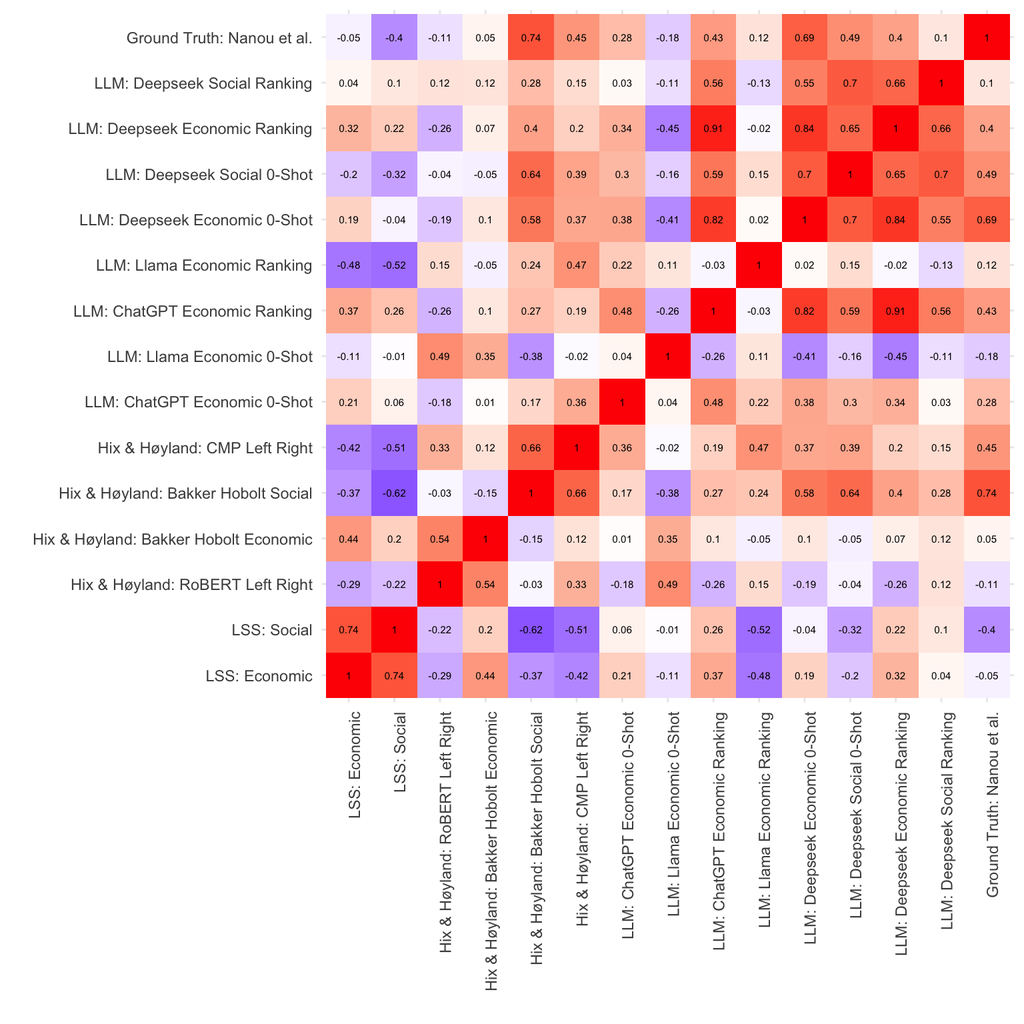

#### Preambles

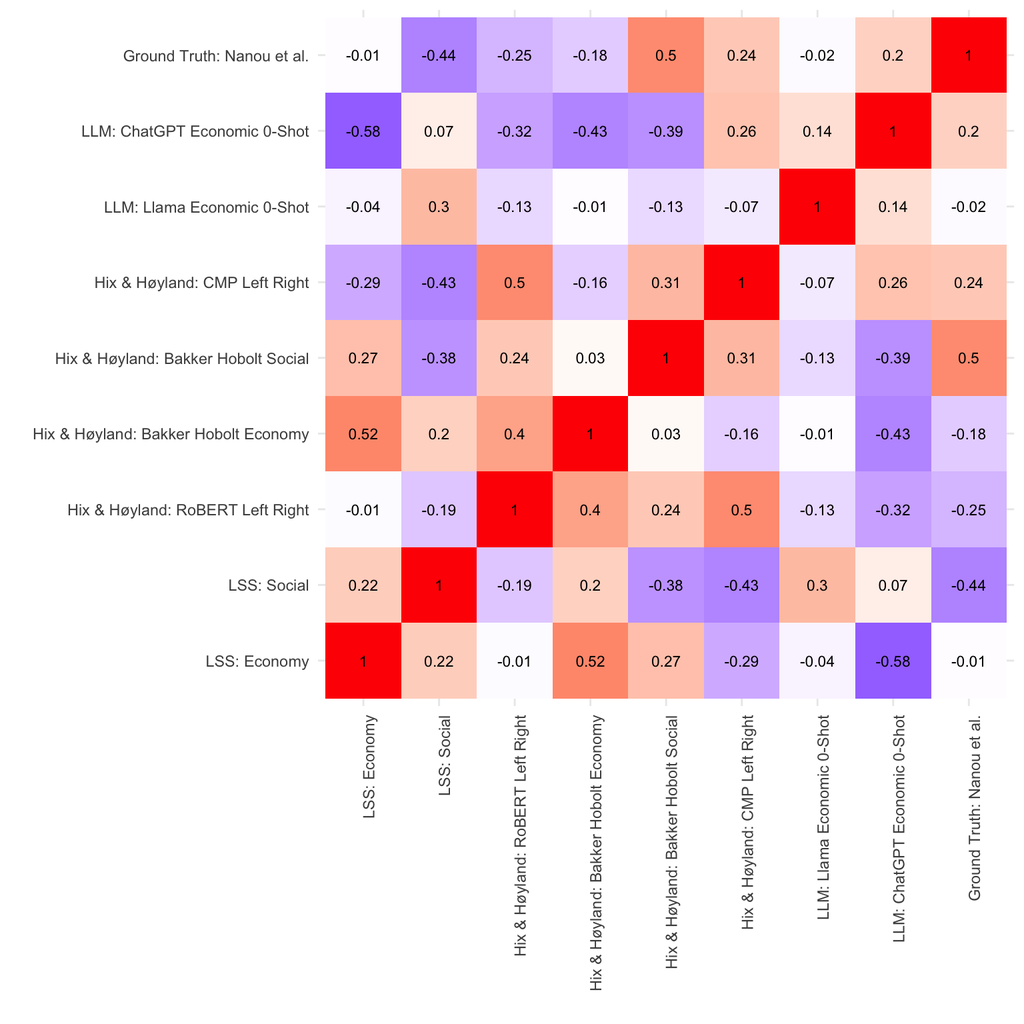

### Correlation Scatter Plots

Each point in these plots represents an averaged score for a broad policy area in a specific time period. The x-axis shows the calculated scores (described in the plot’s title), and the y-axis shows the ground truth. The diagonal gray line represents perfect correlation, while the blue line represents the trend line for the calculated scores. Closer convergence of the blue and gray lines indicates better alignment with the ground truth.

#### Summaries

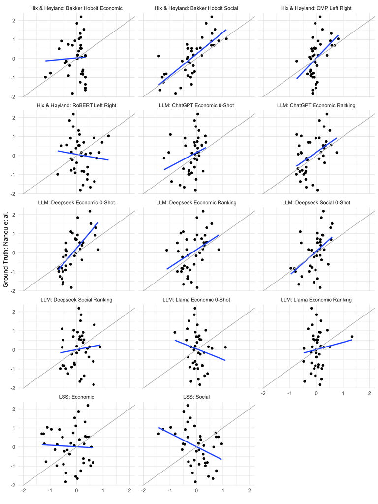

#### Preambles

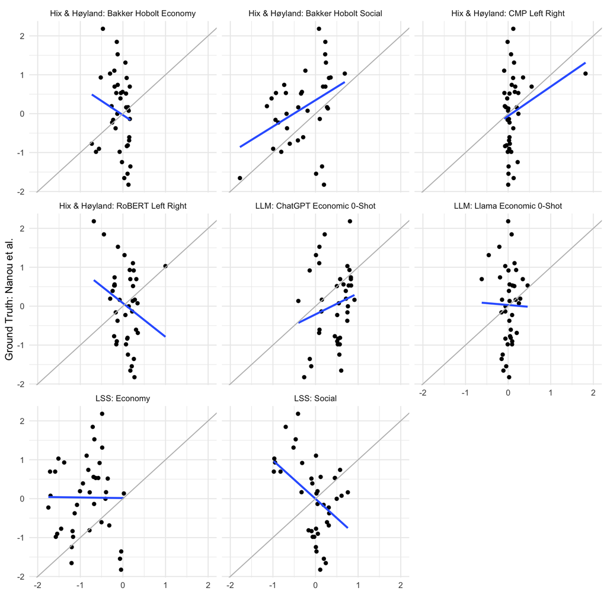

### Variance

The scatter plots above hint that the variance of the calculated scores is low. I examine this in more detail in the following plots. They show that the variance of the computed scores is generally lower than the variance of the ground truth. I address this issue further below.

#### Summaries: Distribution of Z-Scores (Histograms)

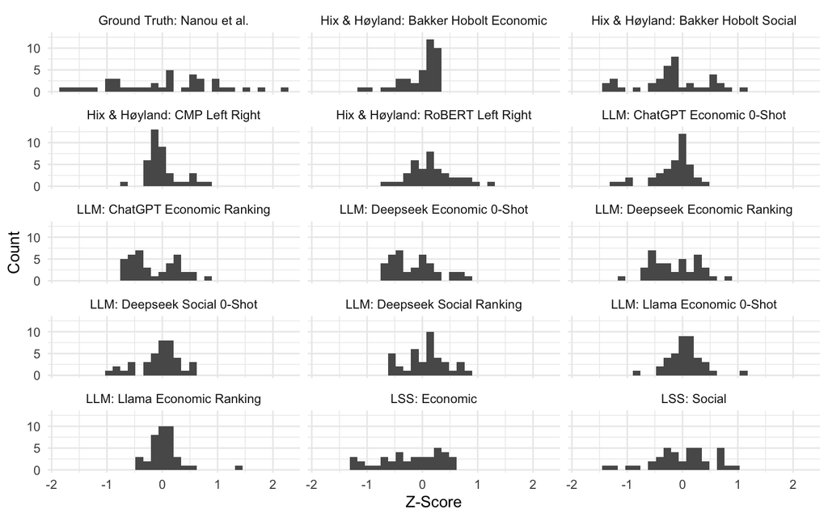

#### Preambles: Distribution of Z-Scores (Histograms)

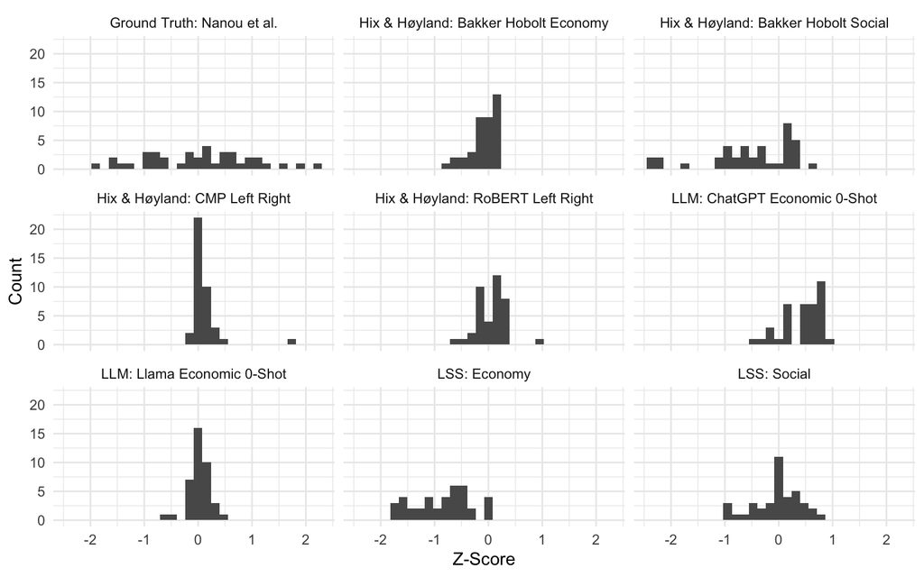

#### Summaries: Distribution of Z-Scores (Box Plots)

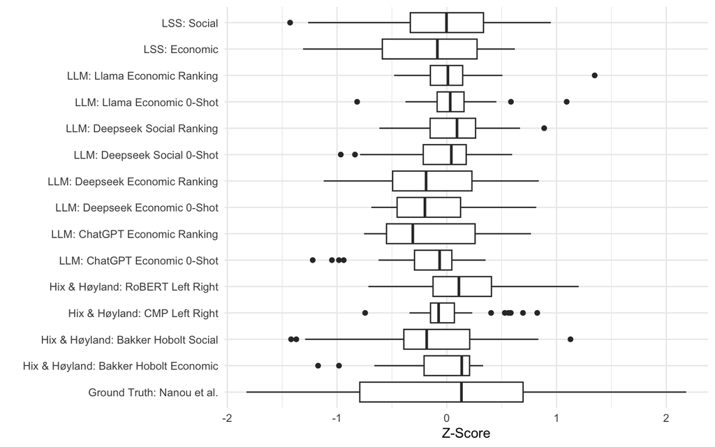

#### Preambles: Distribution of Z-Scores (Box Plots)

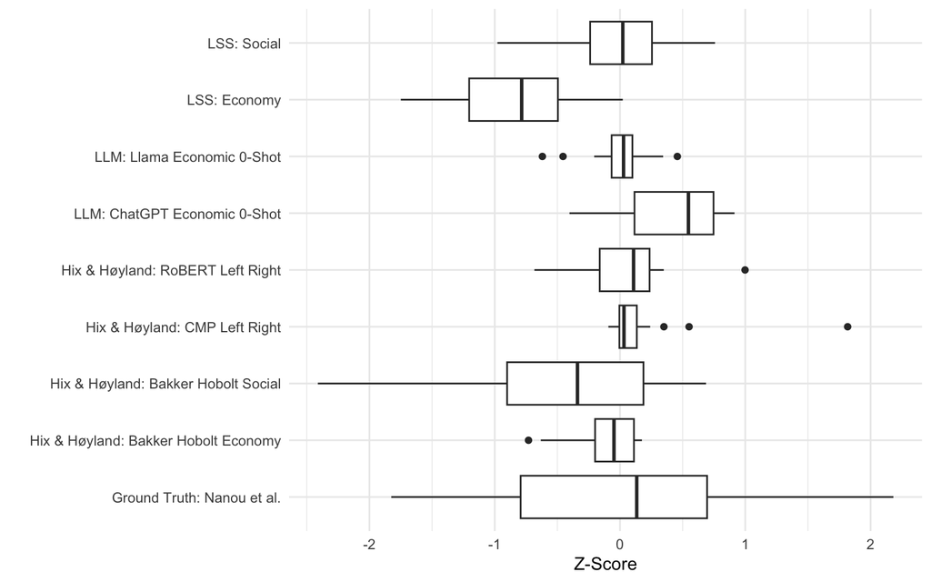

### Mean Absolute Error (MAE)

I calculate the average of the absolute differences between the computed scores and the ground truth. Smaller MAE values indicate that the computed scores are closer to the ground truth.

#### Summaries

|  | Mean Absolute Error |
| --- | --- |
| Hix & Høyland: Bakker Hobolt Social | 0.55 |
| LLM: Deepseek Economic 0-Shot | 0.62 |
| LLM: Deepseek Social 0-Shot | 0.67 |
| Hix & Høyland: CMP Left Right | 0.71 |
| LLM: ChatGPT Economic Ranking | 0.71 |
| LLM: Deepseek Economic Ranking | 0.74 |
| LLM: ChatGPT Economic 0-Shot | 0.78 |
| LLM: Llama Economic Ranking | 0.81 |
| LLM: Deepseek Social Ranking | 0.81 |
| Hix & Høyland: Bakker Hobolt Economic | 0.82 |
| Hix & Høyland: RoBERT Left Right | 0.88 |
| LLM: Llama Economic 0-Shot | 0.90 |
| LSS: Economic | 0.98 |
| LSS: Social | 1.07 |

#### Preambles

|  | Mean Absolute Error |
| --- | --- |
| Hix & Høyland: CMP Left Right | 0.77 |
| LLM: Llama Economic 0-Shot | 0.80 |
| Hix & Høyland: Bakker Hobolt Economy | 0.82 |
| Hix & Høyland: RoBERT Left Right | 0.85 |
| Hix & Høyland: Bakker Hobolt Social | 0.87 |
| LLM: ChatGPT Economic 0-Shot | 0.87 |
| LSS: Social | 1.01 |
| LSS: Economy | 1.19 |

### Adjusted MAE With Variance Penalties

The ground truth has a much higher variance than the computed scores (see histograms and box plots above under “Variance”). To address this, I introduce a variance penalty that penalises the scores for their lack of variance. I do this because I treat a lack of variance as something negative, as it indicates similar scores for different policies. I penalise at the aggregate level to take into account the overall performance of a method.

#### Summaries

|  | Penalised MAE |
| --- | --- |
| Hix & Høyland: Bakker Hobolt Social | 1.30 |
| LSS: Economic | 2.95 |
| LSS: Social | 3.33 |
| LLM: Deepseek Economic 0-Shot | 3.54 |
| LLM: ChatGPT Economic Ranking | 3.67 |
| LLM: Deepseek Economic Ranking | 3.88 |
| LLM: Deepseek Social 0-Shot | 4.41 |
| Hix & Høyland: RoBERT Left Right | 5.06 |
| LLM: ChatGPT Economic 0-Shot | 5.41 |
| LLM: Deepseek Social Ranking | 5.70 |
| Hix & Høyland: Bakker Hobolt Economic | 5.99 |
| Hix & Høyland: CMP Left Right | 7.30 |
| LLM: Llama Economic Ranking | 8.27 |
| LLM: Llama Economic 0-Shot | 8.94 |

#### Preambles

|  | Penalised MAE |
| --- | --- |
| Hix & Høyland: Bakker Hobolt Social | 1.27 |
| LSS: Economy | 4.43 |
| LSS: Social | 5.08 |
| LLM: ChatGPT Economic 0-Shot | 6.58 |
| Hix & Høyland: CMP Left Right | 7.91 |
| Hix & Høyland: RoBERT Left Right | 10.07 |
| Hix & Høyland: Bakker Hobolt Economy | 13.92 |
| LLM: Llama Economic 0-Shot | 20.22 |

## Discussion

Looking at the adjusted MAE with variance penalties, we can see that the Bakker Hobolt Social method used by Hix and Høyland (2024) is closest to the ground truth, both when using a policy’s summary and its preamble. The Bakker Hobolt Social method uses a fine-tuned model, trained on data from the [Manifesto Project](https://manifesto-project.wzb.eu/). It is therefore well equipped to deal with the specific task of scoring EU policies.

In second and third place is the LSS method. This is an interesting finding, as it suggests that this relatively simple natural language processing method is closer to the ground truth than the methods that use complex large language models, when variance is taken into account.

Possible reasons why the LLMs perform worse than the Bakker Hobolt Social or LSS methods are that they are not fine-tuned and are not designed to perform particularly well in the very niche task of classifying EU policies. I also assume that non-fine-tuned LLMs produce a lot of noise, leading to worse results than the LSS method, which is “fine-tuned” in its own way with its seed words.

A possible next step is to fine-tune an LLM to improve its ability to classify policies.

## References

Bakker, Ryan, and Sara Hobolt. 2013. “Measuring Party Positions.” *Political Choice Matters: Explaining the Strength of Class and Religious Cleavages in Cross-National Perspective*, 27–45.

Borrett, Camille, and Moritz Laurer. 2020. “The CEPS EurLex Dataset: 142.036 EU Laws from 1952-2019 with Full Text and 22 Variables.” Harvard Dataverse. https://doi.org/10.7910/DVN/0EGYWY.

Hix, Simon, and Bjørn Høyland. 2024. “Political Ideology, Policy-Loss, and Support for European Integration.”

Lowe, Will, Kenneth Benoit, Slava Mikhaylov, and Michael Laver. 2011. “Scaling Policy Preferences from Coded Political Texts.” *Legislative Studies Quarterly* 36 (1): 123–55. https://doi.org/10.1111/j.1939-9162.2010.00006.x.

Nanou, Kyriaki, Galina Zapryanova, and Fanni Toth. 2017. “An Ever-Closer Union? Measuring the Expansion and Ideological Content of European Union Policy-Making Through an Expert Survey.” *European Union Politics* 18 (4): 678–93. https://doi.org/10.1177/1465116517721657.

Ovádek, Michal. 2021. “Facilitating Access to Data on European Union Laws.” *Political Research Exchange* 3 (1): 1870150. https://doi.org/10.1080/2474736X.2020.1870150.